# Lecture 19

Add a new variable with `mutate()`

Byeong-Hak Choe

bchoe@geneseo.edu

SUNY Geneseo

April 16, 2024

## Announcement

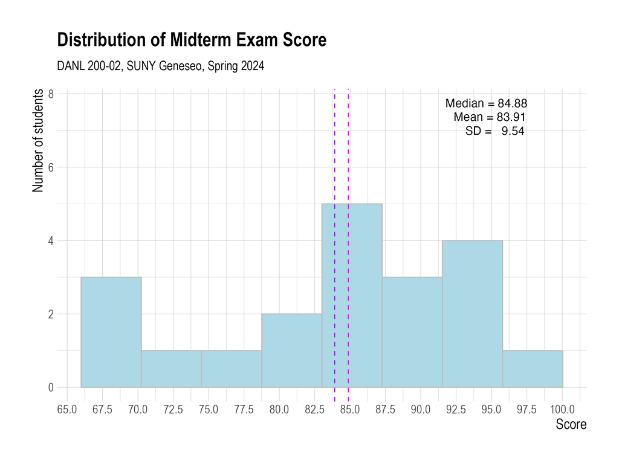

## Announcement

### Homework Assignments

- There will be two more homework assignments.
- The single lowest homework score will be dropped when calculating the total homework score.
- Each homework except for the homework with the lowest score accounts for **25%** of the total homework score.

## Announcement

### Team Project

- A team can be composed of two, three, four, or five members.
- One representative for a team must send Byeong-Hak an email at *bchoe@geneseo* with the following details by April 23, Tuesday, 11:59 P.M:
  - Subject Line: DANL-200-team
  - Email Body:
    - Member 1: Last Name, First Name
    - Member 2: Last Name, First Name
    - Member 3: Last Name, First Name (optional)
    - Member 4: Last Name, First Name (optional)
    - Member 5: Last Name, First Name (optional)

## Announcement

### Team Project

- The project is about presenting your findings through data analysis using `skim`, `ggplot`, and `dplyr` functions on your personal website.
- Think of this project as a more comprehensive homework assignment.
- Details of the project will be announced next week.
  - Each team must choose one `data.frame` for the project.
  - It is okay to use more than one single `data.frames` if the `data.frames` are *related*.
  - While I plan to provide a list of `data.frames` for the project, I give each team an option to freely choose own `data.frame` for the project upon Choe’s approval.
- While this is team work, your website and its corresponding GitHub repository will be independently assessed for the project.

## Data Transformation

### Pipe (`|>`) Operator

- Because the first argument is a `data.frame` and the output is a `data.frame`, `dplyr` verbs work well with the **pipe**, `|>`
  - **Ctrl + Shift + M** for Windows; **command + Shift + M** for Mac.
- The **pipe** (`|>`) takes the thing on its left and passes it along to the function on its right so that
  - `f(x, y)` is equivalent to `x |> f(y)`.
  - e.g., `filter(DATA_FRAME, LOGICAL_STATEMENT)` is equivalent to `DATA_FRAME |> filter(LOGICAL_STATEMENT)`.
- The easiest way to pronounce the **pipe** (`|>`) is “**then**”.
  - The **pipe** (`|>`) is super useful when we have *a chain of data transforming operations* to do.

## Data Transformation

### `dplyr` basics

- `data.frame |> filter(LOGICAL_CONDITIONS)`
- `data.frame |> arrange(VARIABLES)`
- `data.frame |> distinct(VARIABLES)`
- `data.frame |> select(VARIABLES)`
- `data.frame |> rename(NEW_VARIABLE = EXISTING_VARIABLE)`
- `data.frame |> mutate(NEW_VARIABLE = ... )`
- `data.frame |> relocate(VARIABLES)`
- `data.frame |> group_by(VARIABLES)`
- `data.frame |> summarize(NEW_VARIABLE = ...)`
- The subsequent arguments describe what to do with the data.frame, mostly using the variable names.
- The result is a `data.frame`.

# Add new variables with `mutate()`

## Add new variables with `mutate()`

### Arithmetic operations

- `mutate()` is useful to add new variables that are functions of existing variables.
  - New variables can be a result of arithmetic operations.
  - Arithmetic operators: `+`, `-`, `*`, `/`, `^`
  - Modular arithmetic: `%/%` (integer division) and `%%` (remainder).

```r
flights |>
  select(dep_time) |>
  mutate(
    hour = dep_time %/% 100,
    minute = dep_time %% 100
    )
```

## Add new variables with `mutate()`

- A new variable can be based on the new variable within the `mutate()` function.

```r
flights |>
  select(year:day, ends_with("delay"), air_time) |>
  mutate(gain = dep_delay - arr_delay,
         hours = air_time / 60,
         gain_per_hour = gain / hours )
```

## Add new variables with `mutate()`

- `.before`
- `.after`
- We can use the `.before` argument to add the variables to the position of a column:

```r
flights |>
  mutate(
    gain = dep_delay - arr_delay,
    speed = distance / air_time * 60,
    .before = 1  # try different position numbers.
  )
```

- The `.` is a sign that `.before` is an **argument** to the function, not the name of variable.
- In both `.before` and `.after`, we can use the variable name instead of a position number.

```r
flights |>
  mutate(
    gain = dep_delay - arr_delay,
    speed = distance / air_time * 60,
    .after = day
  )
```

## Add new variables with `mutate()`

### Useful creation functions

1. Offsets: `lead()` and `lag()`
2. If-else conditions: `ifelse()`
3. Ranking functions: `min_rank()`, `dense_rank()`, `percent_rank()`, `row_number()`, and more
4. Other useful functions: `log()`, `log10()`, `exp()`, `sqrt()`, `round()`, `as.character()`, `as.numeric()`, `as.integer()`, and more
5. Factor-related functions: `factor()`, `fct_reorder()`, and more
6. String-related functions: `str_detect()`, `str_replace()`, `str_replace_all()`, `str_sub()`, and more

## Add new variables with `mutate()`

### 1. `lead()` and `lag()`

- Offsets: `lead()` and `lag()` allow us to refer to leading or lagging values.
- Offsets
- Change

```r
df <- data.frame( x = 1:10 )

df <- df |>
  mutate(x_lag = lag(x),
         x_lead = lead(x))
```

- A change in GDP in year $y$ and a percentage change in GDP in year $y$ are calculated as follows:

$$\begin{align}
\Delta GDP_{y} = GDP_{y} - GDP_{y-1}
\end{align}$$

$$\begin{align}
\%\Delta GDP_{y} = \frac{GDP_{y} - GDP_{y-1}}{GDP_{y}}
\end{align}$$

```r
df <- data.frame(
  Year = 2015:2022,
  GDP = c(100, 105, 109, 113,
          118, 121, 119, 118))

df <- df |>
  mutate(GDP_chg = GDP - lag(GDP),
         GDP_growth_pct =
           100 * GDP_chg/GDP)
```

## Add new variables with `mutate()`

### 2. `ifelse()`

```r
flight_season <- flights |>
  mutate(summer_month = ifelse(month %in% c(6, 7, 8),
                               TRUE,
                               FALSE))
```

- To create new variables based on a condition, use `ifelse()`
  - `ifelse(CONDITION, <if TRUE>, <else>)`

## Add new variables with `mutate()`

### 3. Ranking functions

```r
rank_me <- data.frame( x = c(10, 5, 1, 5, 5, NA) )

rank_me_asce <- rank_me |>
  mutate(x_min_rank = min_rank(x),
         x_dense_rank = dense_rank(x),
         x_row_number = row_number(x),
         x_perc_rank = percent_rank(x) )

rank_me_desc <- rank_me |>
  mutate(x_min_rank = min_rank(-x), # instead of -x, we can use desc(x)
         x_dense_rank = dense_rank(-x),
         x_row_number = row_number(-x),
         x_perc_rank = percent_rank(-x) )
```

- To create new variables based on an order of values: `min_rank()`, `dense_rank()`, `row_number()`, `percent_rank()`, and more

## Add new variables with `mutate()`

### 4. Other useful functions

```r
df <- data.frame( x = c(1:10) ) |>
  mutate(x_log = log(x),
         x_log10 = log10(x),
         x_exp = exp(x),
         x_sqrt = sqrt(x),
         x_sqrt_round = round(x_sqrt, 2),
         x_fct = factor(x),
         x_chr = as.character(x),
         x_num = as.numeric(x),
         x_int = as.integer(x) )
```

- We can use math functions as well as as.DATATYPE functions:
  - `log()`, `log10()`, `exp()`, `sqrt()`, `round(VAR, digit)`, `factor()`, `as.character()`, `as.numeric()`, `as.integer()`, and more

## Columns: `select()`, `rename()`, `relocate()`, and `mutate()`

Let’s do Question 1 and Question 2 up to Q2e in [Classwork 10](https://bcdanl.github.io/200/danl-cw/danl-200-cw-10.html)!

## Add new variables with `mutate()`

### 5. Factors

- `factor()`
- `factor()` w/ levels
- `fct_reorder()`

```r
df <- data.frame(
  city = c("Rochester", "Buffalo",
           "Geneseo", "Syracus"),
  income = c(80,  82,  70, 75) )

df <- df |>
  mutate( city_fct = factor(city) )

df$city
df$city_fct
```

- In `R`, factors are categorical variables, variables that have a fixed and known set of possible values.
- We can use a factor variable to sort categories in a useful way.

```r
NY_cities <- c("Geneseo", "Rochester",
               "Buffalo", "Syracus")
df <- df |>
  mutate(city_fct_new =
           factor(city,
                  levels = NY_cities)
  )

levels(df$city_fct)
levels(df$city_fct_new)
```

- If we ever need to set the order of levels directly, we can do so with `levels`.

```r
df <- df |>
        mutate(city_reorder = fct_reorder(city_fct, income) )
```

- We can reorder the levels using `fct_reorder(f, x, fun)`, which can take three arguments.
  - `f`: the factor whose levels we want to modify.
  - `x`: a numeric vector that we want to use to reorder the levels.
  - Optionally, `fun`: a function that’s used if there are multiple values of `x` for each value of `f`.
  - The default value for `fun` is *median*.

## Add new variables with `mutate()`

### `ggplot` with a factor variable - Sorted bar chart/dot plot

- It’s often useful to change the order of the factor levels in a visualization.
- Imagine we want to explore the average income across cities.

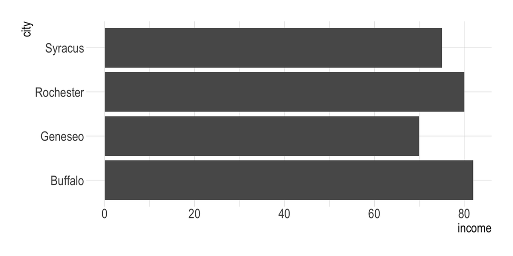

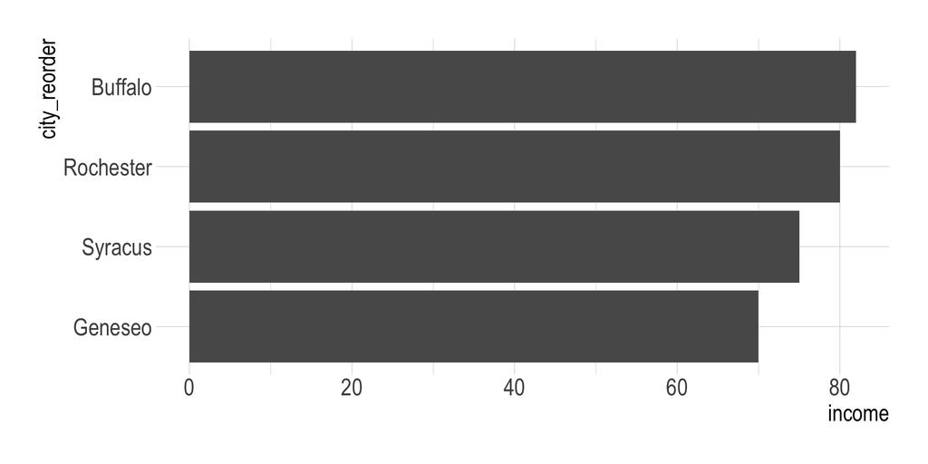

## Add new variables with `mutate()`

### 6. Strings

- `str_detect()`
- `str_replace()`
- `str_sub()`

```r
df_str <- data.frame(
  fruit = c("apple", "banana", "pear")
)

df_str <- df_str |>
  mutate( fruit_e = str_detect(fruit, "e")
  )
```

- `str_detect()` returns `TRUE` if a character value matches a pattern. Otherwise, `FALSE`.

```r
df_str <- df_str |>
  mutate(fruit_replace = str_replace(fruit, "a", "-"),
         fruit_replace_all = str_replace_all(fruit, "a", "-")
         )
```

- `str_replace()` and `str_replace_all()` allow us to replace matches with new strings.
- `str_replace_all()` can perform multiple replacements by supplying a named vector.

```r
df_str <- df_str |>
  mutate(fruit_sub1 = str_sub(fruit, 1, 3),
         fruit_sub2 = str_sub(fruit, -3, -1)
  )
```

- We can extract parts of a string using `str_sub()`.
- `str_sub()` takes `start` and `end` arguments which give the position of the substring.

## Columns: `select()`, `rename()`, `relocate()`, and `mutate()`

Let’s do Q2f and Q2g in [Classwork 10](https://bcdanl.github.io/200/danl-cw/danl-200-cw-10.html)!